# Bent Winter 2002

R. G. Cronce

12/19/2019

# Bent Brain Ticklers, Winter 2002

## Problem 1

```
Two dice, one red and one white,
are thrown. The number shown on
the red die is divided by the number
shown on the white die. What is the
expected value of this quotient?

-- William A. Whitworth, 1901
```

Solution: Should just be able to enumerate these without much difficulty. Consider each case of the red die (1:6) and the white die (1:6) for a matrix of 36 values. The mean value should be the desired result.

```
       ...... Red ............
White  1   2   3   4   5   6
1      1   2   3   4   5   6
2      1/2 2/2 3/2 4/2 5/2 6/2
3      1/3 2/3 3/3 4/3 5/3 6/3
4      1/4 2/4 3/4 4/4 5/4 6/4
5      1/5 2/5 3/5 4/5 5/5 6/5
6      1/6 2/6 3/6 4/6 5/6 6/6
```

Now - is there a clever way of summing these or do we just use brute force? We can sum the numerators on each row as 1+2+3+4+5+6 = 21 and then find a common denominator to add the row sums.

```
Total = 21*(1/1+1/2+1/3+1/4+1/5+1/6)
```

The least common denominator is 60, so:

```
Total = 21/60*(60+30+20+15+12+10)
      = 21/60*147
```

The mean result is:

```
Mean = Total/36 = 21/60*147/36
     = (21*147)/(60*36)
     = (3*7*3*7*7)/(2*2*3*5*2*2*3*3)
     = 7*7*7/(2*2*3*5*2*2)
     = 343/240
     ~ 1.429167
```

Just FYI - this is one line of R code

```r
mean(outer(1:6,1:6,"/"))
```

```
## [1] 1.429167
```

## Problem 2

```
Two painters accept a job painting
a room. Al can do the flat work in
two hours and the trim work in one
hour. Ben can do the flat work in
three hours and the trim work in two
hours. What is the minimum time, in
minutes, that the two painters can
paint the room if they divide the
work in the optimum manner?

-- William S. Alderson, MI E’43
```

Solution: this is like distance=rate*time

```
Intuitively it seems like the work should
be partitioned based on the relative
ability of the workers.  For example:

If they are equal speed then each does
half the work.

If one is 2X faster then they should
get 2X of the job.

When there are two jobs -- how do we
optimally partition this?

There must be an easier way to figure this out but
I am failing to see it.

Al flat rate  = 1/2 job per hour
Al trim rate  = 1/1 job per hour
Ben flat rate = 1/3 job per hour
Ben trim rate = 1/2 job per hour

If Ben did the trim and Al the flat then the
whole job would take 2 hours.  We should be
able to improve on that.

Let Al do all the trim in 1 hour and Ben
would complete 1/3 of the flat.  This leaves
2/3 of the flat with both working on it:

t*(1/2+1/3) = 2/3
t*(3/4+1/2) = 1
t*(5/4) = 1
t = 4/5 hours

Total = 1.8 hours

Is this the best we can do?  Let's try analytically:

pf = percent of flat work job performed by Al
pt = percent of trim work job performed by Al

Al_time = pf/(1/2)+pt/(1/1)
Ben_time = (1-pf)/(1/3)+(1-pt)/(1/2)

Al_time = Ben_time

2*pf + pt = 3*(1-pf)+2*(1-pt)
5*pf       = 5 - 3*pt
pf         = 1 - 3/5 * pt

So: Al_time = 2*(1-3/5*pt) + pt
            = 2 - 6/5*pt + pt
            = 2 - 1/5*pt

I want to minimize this so need maximum pt = 1, pf = 2/5

Al_time = 9/5 = 1.8
Ben_time = 3/5*1/3 + 0 = 9/5 = 1.8

I guess this confirms my original guesstime for full time on trim.

Should I try Monte-Carlo just for grins???
```

```r
# Uniform random percent of each job performed by Al
# Note that I added the underscore to prevent name
# collision with R functions
p_f=runif(100000)
p_t=runif(100000)
al_time = 2*p_f + p_t
ben_time = 3*(1-p_f) + 2*(1-p_t)

# We aren't done until the larger of these two have finished
job_time = ifelse(al_time>ben_time,al_time,ben_time)

# The best solution is the min of this value
print(paste0('Best time = ',min(job_time)))
```

```
## [1] "Best time = 1.80295048025437"
```

```r
# Allocation for this optimum
print(paste0('Portion of flat work done by Al = ',p_f[which.min(job_time)]))
```

```
## [1] "Portion of flat work done by Al = 0.40230026957579"
```

```r
print(paste0('Portion of trim work done by Al = ',p_t[which.min(job_time)]))
```

```
## [1] "Portion of trim work done by Al = 0.995074355509132"
```

Which confirms the analysis above. Al does all the trim and 40% of the flat work. Ben does the remaining 60% of the flat work.

## Problem 3

```
Walking near a pond, a 45 kg boy
finds a hemispherical concrete shell
2.5 cm thick and tries to use it as a
boat. With the boy aboard and
crouching low for stability, the shell
floats with 10 cm of freeboard. If the
specific gravity of the concrete is 2.5,
what is the outside diameter of the
hemisphere?

-- Craig K. Galer, MI A’77
```

Solution: this goes back to a previous problem involving the volume of the lower portion of a hemisphere along with some interesting calculations.

For a full hemisphere:

```
R = outside radius of the hemisphere
Vo = volume of the outside of the hemisphere
Vi = volume of the (hollow) inside of the hemisphere
Mh = mass of the hemisphere

Vo = 2/3*pi*R^3
Vi = 2/3*pi*(R-2.5)^3
Mh = (Vo-Vi)*2.5

Total Mass of "boat" = Mh + 45 kg

Volume of Water displaced = lower part of hemisphere (all but top 10 cm).

For a sphere of radius = R, height of h from bottom

V = pi*R*h^2 - pi*h^3/3

Volume of water = pi*R*(R-10cm)^2 - pi*(R-10cm)^3/3

If we assume water is 1000 kg per cubic meter and put everything in kg, meters:

(pi*R*(R-0.1)^2 - pi*(R-0.1)^3/3)*1000 = (Vo-Vi)*2.5*1000 + 45
        = (2/3*pi*R^3 - 2/3*pi*(R-0.025)^3)*2.5*1000+45

2000*pi*R^3/3 - 100*pi*R^2 + pi/3 = 125*pi*R^2 - 25*pi*R/8 + 5*pi/192 + 45

2000*pi*R^3/3 - 225*pi*R^2 + 25*pi*R/8 - 45 + 59*pi/192 = 0

R = 0.436911963870549 meters

Diameter = 2*R ~ 0.873823927741098 meters

(OK - I confess I used sympy in a separate ipython window for the heavy lifting)

Check for sanity:
```

```r
foo = function(r) {
    return(2000*pi*r^3/3 - 225*pi*r^2 + 25*pi*r/8 - 45 + 59*pi/192)
}

r=uniroot(foo,c(0,1))$root
print(paste0("Numerical solution for r     = ",r))
```

```
## [1] "Numerical solution for r     = 0.436911989462304"
```

```r
r=0.436911963870549   # outside radius of hemisphere (from sympy)
r2=r-0.025            # inside radius of hemisphere
freeboard=0.1         # height from water to top of hemisphere
boy_mass=45           # mass of the passenger

water_volume = pi*r*(r-freeboard)^2 - pi*(r-freeboard)^3/3

displaced_mass = water_volume*1000
concrete_mass = (2/3*pi*r^3-2/3*pi*r2^3)*2.5*1000

total_mass = concrete_mass + boy_mass

print(paste0('Outside radius of hemisphere = ',r))
```

```
## [1] "Outside radius of hemisphere = 0.436911963870549"
```

```r
print(paste0('Outside diameter of hemisphere = ',2*r))
```

```
## [1] "Outside diameter of hemisphere = 0.873823927741098"
```

```r
print(paste0('water volume     = ',water_volume))
```

```
## [1] "water volume     = 0.115755577438206"
```

```r
print(paste0('displaced mass   = ',displaced_mass))
```

```
## [1] "displaced mass   = 115.755577438206"
```

```r
print(paste0('concrete mass    = ',concrete_mass))
```

```
## [1] "concrete mass    = 70.7555774382058"
```

```r
print(paste0('total craft mass = ',total_mass))
```

```
## [1] "total craft mass = 115.755577438206"
```

We should also be able to do this graphically:

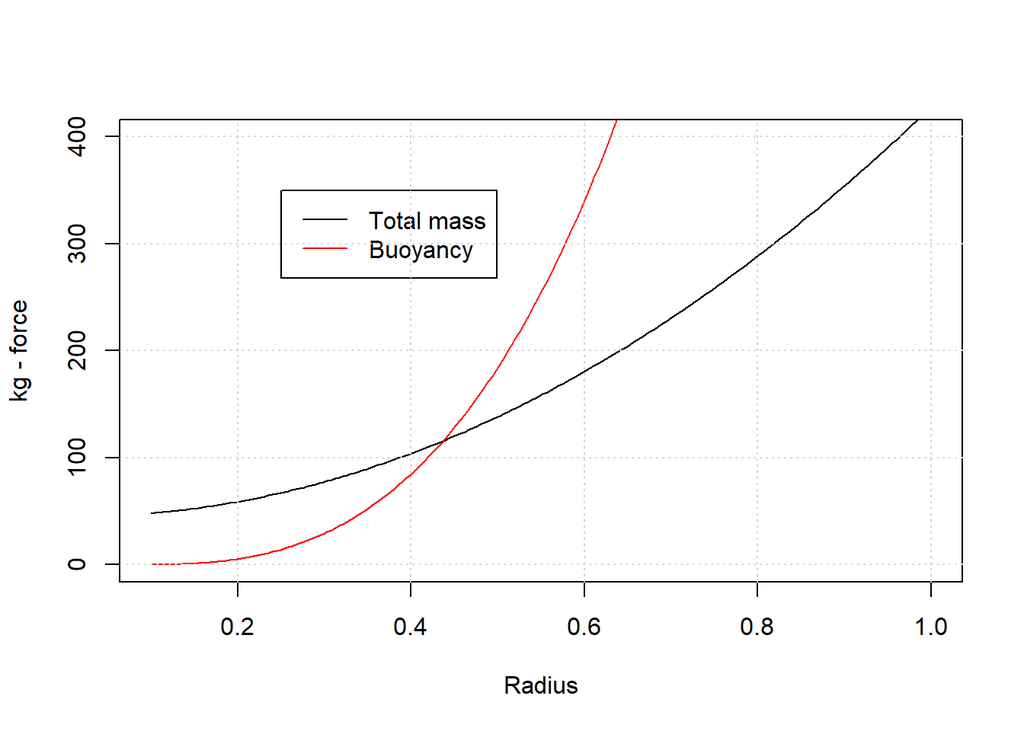

```r
spec_gravity=2.5   # Given in problem definition
freeboard=0.10     # Given in problem definition
mass_boy=45        # Given in problem definition

water_density=1000 # kg per m^3 (assumed water density)

r=seq(0.1,1,length.out=200)   # Range of hemisphere radii to be explored

outside_volume=2/3*pi*r^3
inside_volume=2/3*pi*(r-0.025)^3
concrete_mass=(outside_volume-inside_volume)*spec_gravity*water_density
total_mass = concrete_mass + mass_boy

## For bottom part of hemisphere (height = h)
##
##    V = pi*R*h^2 - pi*h^3/3

displaced_volume = pi*r*(r-0.1)^2-pi*(r-0.1)^3/3
buoyancy=displaced_volume*water_density

plot(r,total_mass,type='l',xlab='Radius',ylab='kg - force',xlim=c(0.1,1),ylim=c(0,400))
lines(r,buoyancy,col='red')
legend(0.25,350,c('Total mass','Buoyancy'),lty="solid",col=c("black","red"))
grid()
```

Clearly, for small radii the buoyancy is too small to support the mass of the shell and passenger. When the shell gets *large enough* then the boat will float.

To get a meaningful result we would need to zoom in the plot but it appears that a radius of (approximately) 0.44m is sufficient.

## Problem 4

```
In how many different ways can
eight queens be placed on a chess
board such that no queen threatens
another queen and no queen occupies
a square that is on either major
diagonal? A solution is considered
different if it is not a rotation or
reflection of another solution.

-- David H. Westwood, MN A’43
```

## Problem 5

```
During a recent game of fivecard-
draw poker, played with a
standard deck of cards, I was dealt a
hand with the following characteristics.
It contained no aces or face
cards and had no two cards of the
same value. All four suits were
present. The total value of the odd
cards equaled the total value of the
even cards. There were no three-card
straights. The total value of the black
cards was 10, and the total value of
the hearts was 14. And the card with
the lowest value was a spade.
Precisely what were the five cards?

-- nearly impossible Brain Bafflers
by Tim Sole and Rod Marshall
```

Solution: Note that when I checked the solution I realized my final solution was correct but in my process I made a mistake. I missed the fact that the two Hearts could be 10+4 so I have added that to the analysis. There is no feasible hand with these cards so it did not affect the final solution.

[output not shown]

## Bonus

```
Ann and Bev play a game of
random tic-tac-toe. They start with a
tic-tac-toe grid with the boxes
labeled 1 through 9. Next, they
shuffle a deck of cards consisting of
the ace, 2, 3, 4, 5, 6, 7, 8, and 9 of
spades. They then take turns
drawing cards, without replacement,
and placing their initials in the
squares corresponding to the card
drawn until a winner is determined.
If Ann draws first, what is her
probability of winning, ignoring
games that end in a draw?

-- The Surprise Attack in
Mathematical Problems
by L. A. Graham
```

Solution: Consider the tic-tac-toe grid as shown:

```
+---+---+---+
| 1 | 2 | 3 |
+---+---+---+
| 4 | 5 | 6 |
+---+---+---+
| 7 | 8 | 9 |
+---+---+---+

A win occurs when one player has any of the following
eight combinations:

1-2-3
4-5-6
7-8-9
1-4-7
2-5-8
3-6-9
1-5-9
3-5-7

No one can win until they have three numbers.

Ann gets to three numbers first.  There are 84 possible 3 number
combinations from 9 numbers.  Of these, 8 will win so the
probability that she wins is 8/84.

Now it gets complicated since the remaining probabilities are
conditional on Ann failing.

I tried to do this analytically and it was nonsense.

I suspect Bayes Theorem could be useful - but I will punt.

What about Monte-Carlo?
```

```r
num_trial=10000

win_code = function(s) {
    r=0
    if (all(c(1,2,3) %in% s)) {r=1}
    if (all(c(4,5,6) %in% s)) {r=2}
    if (all(c(7,8,9) %in% s)) {r=3}
    if (all(c(1,4,7) %in% s)) {r=4}
    if (all(c(2,5,8) %in% s)) {r=5}
    if (all(c(3,6,9) %in% s)) {r=6}
    if (all(c(1,5,9) %in% s)) {r=7}
    if (all(c(3,5,7) %in% s)) {r=8}
    return(r)
}

result=c()
for (i in 1:num_trial) {
    ann=c()
    bev=c()
    s=sample(1:9)
    for (k in 1:9) {
        if (k%%2 == 1) {
            ann=c(ann,s[k])
            r=win_code(ann)
            if (r > 0) {
                result=c(result,1)
                break
            }
        } else {
            bev=c(bev,s[k])
            r=win_code(bev)
            if (r>0) {
                result=c(result,2)
                break
            }

        }
    }
}
print(paste0("Ann wins = ",sum(result==1)/length(result)))
```

```
## [1] "Ann wins = 0.672579537651637"
```

```r
print(paste0("Bev wins = ",sum(result==2)/length(result)))
```

```
## [1] "Bev wins = 0.327420462348363"
```

```r
print(paste0("Draws    = ",num_trial-length(result)))
```

```
## [1] "Draws    = 1262"
```

So Ann wins about 2/3 of the time and Bev wins 1/3 of the time. This ignores the draws. It is sort of interesting that draws only happen about 13% of the time with random square selection.

They actually solve this analytically by looking at every possible tic-tac-toe grid and counting the solutions. The likelihood that Ann wins (discounting ties) is precisely 0.67.

## Double Bonus

```
Using only a pair of
compasses, locate the midpoint
between two given points, using
fewer than 10 compass operations.

-- Elvin Greene, NJ Gamma’52
```

I looked at the solution and I could not follow it mentally. Need to make a drawing and try it.